# Vienna Elections 2020: Age profile of electoral candidates

Austria

elections

OCR

regex

reactable

gt

An empirical look at candidates’ age.

Author

Roland Schmidt

Published

10 Oct 2020

# 1 Setup

**Code: Load packages**

```r
library(tidyverse)
library(here)
library(extrafont)
loadfonts(device = "win", quiet = T)
library(hrbrthemes)
hrbrthemes::update_geom_font_defaults(
  family = "Roboto Condensed",
  size = 3.5,
  color = "grey50"
)
library(scales)
library(knitr)
library(paletteer)
library(ggtext)
library(glue)
library(pdftools)
library(svglite)
library(tictoc)
library(tidytext)
library(gt)
library(reactable)
library(reactablefmtr)
library(ggforce)
library(ggiraph)
library(htmltools)
```

**Code: Define rmarkdown options**

```r
knit_hooks$set(wrap = function(before, options, envir) {
  if (before) {
    paste0("<", options$wrap, ">")
  } else {
    paste0("</", options$wrap, ">")
  }
})

knitr::opts_chunk$set(
    fig.align = "left",
    message = FALSE,
    warning = FALSE,
    dev = "svglite",
#   dev.args = list(type = "CairoPNG"),
    dpi = 300,
    out.width = "100%"
)
options(width = 180, dplyr.width = 150)
```

**Code: Define plot theme, party colors, caption**

```r
plot_bg_color <- "white"

caption_table <- "Source:\ndata: https://www.wien.gv.at/politik/wahlen/grbv/2020/ analysis: Roland Schmidt | @zoowalk | https://werk.statt.codes"

theme_post <- function() {
  hrbrthemes::theme_ipsum_rc() +
    theme(
      plot.background = element_rect(fill = plot_bg_color, color=NA),
      panel.background = element_rect(fill = plot_bg_color, color=NA),
      #panel.border = element_rect(colour = plot_bg_color, fill=NA),
      #plot.border = element_rect(colour = plot_bg_color, fill=NA),
      plot.margin = ggplot2::margin(l = 0,
                           t = 0.25,
                           unit = "cm"),
      plot.title = element_markdown(
        color = "grey20",
        face = "bold",
        margin = ggplot2::margin(l = 0, unit = "cm"),
        size = 11
      ),
      plot.title.position = "plot",
      plot.subtitle = element_text(
        color = "grey50",
        margin = ggplot2::margin(t = 0.2, b = 0.3, unit = "cm"),
        size = 10
      ),
      plot.caption = element_text(
        color = "grey50",
        size = 8,
        hjust = c(0)
      ),
      plot.caption.position = "panel",
      axis.title.x = element_text(
        angle = 0,
        color = "grey50",
        hjust = 1
      ),
      axis.text.x = element_text(
        size = 9,
        color = "grey50"
      ),
      axis.title.y = element_blank(),
      axis.text.y = element_text(
        size = 9,
        color = "grey50"
      ),
      panel.grid.minor.x = element_blank(),
      panel.grid.major.x = element_blank(),
      panel.grid.minor.y = element_blank(),
      panel.spacing = unit(0.25, "cm"),
      panel.spacing.y = unit(0.25, "cm"),
      strip.text = element_text(
        angle = 0,
        size = 9,
        vjust = 1,
        face = "bold"
      ),
      legend.title = element_text(
        color = "grey30",
        face = "bold",
        vjust = 1,
        size = 7
      ),
      legend.text = element_text(
        size = 7,
        color = "grey30"
      ),
      legend.justification = "left",
      legend.box = "horizontal", # arrangement of multiple legends
      legend.direction = "vertical",
      legend.margin = ggplot2::margin(l = 0, t = 0, unit = "cm"),
      legend.spacing.y = unit(0.07, units = "cm"),
      legend.text.align = 0,
      legend.box.just = "top",
      legend.key.height = ggplot2::unit(0.2, "line"),
      legend.key.width = ggplot2::unit(0.5, "line"),
      text = element_text(size = 5)
    )
}

data_date <- format(Sys.Date(), "%d %b %Y")

my_caption <- glue::glue("data: https://www.wien.gv.at/politik/wahlen/grbv/2020/\nanalysis: Roland Schmidt | @zoowalk | https://werk.statt.codes")
```

# 2 Context

Elections in Vienna are today and while glancing through the electoral lists I couldn’t help but paying attention to candidates’ birth years. Maybe that’s an age thing… This got me thinking that I haven’t seen any more systematic analysis of parties’/candidates’ age profile. So as a modest contribution to this end, here are my two cents. Again, I’ll focus mainly on the pertaining steps in R and related number crunching. Due to a lack of time and not being an expert on Vienna’s electoral system, I’ll be brief when it comes to substantive matters. But the presented results hopefully provide sufficient material to dig into.

As always, if you see any glaring error or have any constructive comment, feel free to let me now (best via twitter DM).

# 3 Data

Again, as so often, the trickiest part is to get the data ‘liberated’ from the format it is provided in. The entire list of candidates is published in [this pdf](https://www.wien.gv.at/politik/wahlen/grbv/pdf/amtsblatt2020.pdf). Note that there are three lists: One for the city council (‘Gemeinderat’; composed on the basis of the results in 18 multi-member electoral districts), one for the 23 district councils (‘Bezirksrat’; one in each district), and the ‘city election proposal’ (‘Stadtwahlvorschlag’; admittedly a somewhat clumsy translation). The latter doesn’t constitute a body in itself, but serves to allocate mandates which remained unassigned after counting the votes for the city council (‘zweites Ermittlungsverfahren’/similar to the d’Hondt procedure).

When it comes to extracting the data from the linked pdf, a difficulty may arise due to the two-column format of the document. Hence, simple row-wise extraction doesn’t help much since it would put candidates together which could be from different parties. Similarly, simply isolating the two columns and extracting candidates would also not do the trick since breaks betwee parties, districts etc run over two, and not one column. To illustrate this, I resorted to cutting edge technology and drew the two arrows below:

[figure not shown]

Luckily, the [`tabulizer` package](https://docs.ropensci.org/tabulizer/) is not only very powerful when it comes to extracting text/data from a pdf, it is also sophisticated enough to take into consideration the text flow highlighted above. I am not familiar with the underlying heuristic, but I assume it is contingent on consistently formatted section headings. Hence, empowered with this tool, retrieving the text becomes rather effortless. The subsequent steps are a battery of regular expressions to extract the specific data we are interested in. To see the code, unfold the snippets below.

**Code: Extract text from pdf**

```r
df_raw <- tabulizer::extract_text(file=here::here("_blog_data",
                                                  "vienna_elections_2020",
                                                  "amtsblatt2020.pdf"),
                        pages=c(1:115),
                        encoding="UTF-8") %>%  #capital letters of UTF!
  enframe(name=NULL,
          value="text_raw")
```

**Code: Extract data of interest (regex)**

```r
df_clean <- df_raw %>%
  ungroup() %>%
  mutate(text_split=str_split(text_raw, regex("\r\n\\s*(?=\\d+\\.)"))) %>%
  unnest_longer(text_split) %>%
  mutate(text_split=text_split %>% str_squish() %>% str_trim()) %>%
  mutate(text_split=str_split(text_split, ".(?=Zustellungsbevollmächtigte(r)? Vertreter(in)?)")) %>%
  unnest_longer(text_split)

# get Listenplatz ------------------------------------------------------------

df_clean <- df_clean %>%
  mutate(listenplatz=str_extract(text_split, regex("^\\d+\\.?\\s+(?!Bezirk)")) %>%
           str_extract(., "\\d*") %>% as.numeric())

# get elections -----------------------------------------------------------

df_clean <- df_clean %>%
  mutate(election=text_raw %>% str_extract(., regex("(?<=[A-Z]\\.)\\s*[A-z]+wahl(en)?", dotall = T)) %>%
           str_trim(., side=c("both"))) %>%
  tidyr::fill(election, .direction="down")


# electoral district --------------------------------------------------------------
df_clean <- df_clean %>%
    mutate(wahlkreis=case_when(election=="Bezirksvertretungswahlen" ~ str_extract(text_split, "\\d{1,2}\\. Bezirk"),
                             election=="Gemeinderatswahl"~ str_extract(text_split, regex("Wahlkreis.*?(?=[:upper:]{2,}?)",
                                                                                     dotall = T,
                                                                                     multiline = T)),
                             election=="Stadtwahl" ~ as.character("Stadtwahl"),
                             TRUE ~ as.character("missing"))) %>%
  mutate(wahlkreis=str_trim(wahlkreis, side=c("both"))) %>%
  tidyr::fill(wahlkreis, .direction="down") %>%
  mutate(wahlkreis=str_remove(wahlkreis, "Wahlkreis ") %>%
           str_remove(., regex("\\(.*\\)")) %>%
           str_trim(., side=c("both")))


# other -------------------------------------------------------------------

df_clean <- df_clean %>%
  mutate(page=text_raw %>% str_extract(., regex("Seite \\d+")) %>% str_extract(., "\\d+") %>%
           as.numeric()) %>%
  mutate(name=str_extract(text_split, regex("(?<=\\d\\.\\s?).*?(?=,\\s?\\d{4},)")) %>%
           str_trim(., side=c("both"))) %>%
  mutate(first_name=text_split %>% str_extract(., regex("[:alpha:]*(?=,\\s?\\d+)"))) %>%
  mutate(year_birth=text_split %>% str_extract(., regex("\\d{4}")) %>%
           as.numeric()) %>%
  mutate(year_interval=cut(year_birth, seq(1930, 2005, 5))) %>%
  mutate(plz=text_split %>% str_extract(., regex("\\d{4}\\s(?=Wien)")) %>%
           str_trim(., side=c("both")))


# get party ---------------------------------------------------------------

df_clean <- df_clean %>%
  mutate(party=text_split %>% str_extract(., regex("(?<=^Zustellung)[:alpha:]*$"))) %>%
  mutate(party=case_when(lead(listenplatz==1) ~ str_extract(text_split, regex("\\w+$")),
                         TRUE ~ NA_character_)) %>%
  tidyr::fill(party, .direction = "down") %>%
  mutate(party=party %>%
             as_factor() %>%
             fct_relevel(., sort) %>%
             fct_relevel(., "SPÖ", "FPÖ", "GRÜNE", "ÖVP", "NEOS"))


# wrap up -----------------------------------------------------------------

df_clean <- df_clean %>%
  mutate(wahlkreis_plz=str_extract(wahlkreis, regex("\\d+")) %>%
           as.numeric()+100) %>%
  mutate(wahlkreis_plz=wahlkreis_plz %>% as.character() %>% paste0(., "0")) %>%
  mutate(wahlkreis_plz=case_when(str_detect(wahlkreis, "Zentrum") ~ "1010, 1040, 1050, 1060",
                                 str_detect(wahlkreis, "Innen") ~ "1070, 1080, 1090",
                                 str_detect(wahlkreis, "Leopoldstadt") ~ "1020",
                                 str_detect(wahlkreis, "Landstraße") ~ "1030",
                                 str_detect(wahlkreis, "Favoriten") ~ "1100",
                                 str_detect(wahlkreis, "Simmering") ~ "1110",
                                 str_detect(wahlkreis, "Meidling") ~ "1120",
                                 str_detect(wahlkreis, "Hietzing") ~ "1130",
                                 str_detect(wahlkreis, "Penzing") ~ "1140",
                                 str_detect(wahlkreis, "Rudolf") ~ "1150",
                                 str_detect(wahlkreis, "Ottakring") ~ "1160",
                                 str_detect(wahlkreis, "Hernals") ~ "1170",
                                 str_detect(wahlkreis, "Währing") ~ "1180",
                                 str_detect(wahlkreis, "Döbling") ~ "1190",
                                 str_detect(wahlkreis, "Brigittenau") ~ "1200",
                                 str_detect(wahlkreis, "Floridsdorf") ~ "1210",
                                 str_detect(wahlkreis, "Donaustadt") ~ "1220",
                                 str_detect(wahlkreis, "Liesing") ~ "1230",
                                 TRUE ~ as.character(wahlkreis_plz))) %>%
  mutate(residence=case_when(
    str_detect(wahlkreis_plz, plz) ~ "inside",
    !str_detect(wahlkreis_plz, plz) ~ "outside",
    TRUE ~ as.character("missing"))) #%>%


df_clean <- df_clean %>%
  select(-text_raw) %>%
  filter(!is.na(listenplatz))
```

After these few steps we have a searchable/sortable table of all candidates (or better candidatures since one person can be candidate on multiple districts/lists). There have been 8,983 candidatures by 5,038 individuals.

The table essentially provides all necessary data for the subsequent analysis. While the pdf does not include the exact birth date of each candidate, it provides us with their birth years which we can take as a proxy for age. Note that I also extracted candidates’ residence zip code to see how often place of residence and candidature actually overlap (see below).

## 3.1 Result

**Code: Table with all candidates**

```r
tb_all <- reactable(df_clean %>%
            select(election, wahlkreis, party, name, listenplatz, year_birth, plz),
          columns=list(election=colDef(name="Wahl", width=130),
                       wahlkreis=colDef(name="Wahlbezirk", width=100),
                       party=colDef(name="Partei", width=50),
                       name=colDef(name="KandidatIn"),
                       listenplatz=colDef(name="Listenplatz",
                                          width=70,
                                          align="center"),
                       year_birth=colDef(name="Geburtsjahr", width=90),
                       plz=colDef(name="PLZ Wohnort", width=90)),
          bordered=F,
          compact = TRUE,
          highlight = TRUE,
          style = list(fontSize = "10px"),
          filterable = TRUE,
          defaultPageSize = 23,
          theme = reactablefmtr::nytimes()) %>%
          add_title(title= "WIEN-WAHL 2020: Liste aller KandidatInnen") %>%
          reactablefmtr::add_source(source=caption_table)
```

WIEN-WAHL 2020: Liste aller KandidatInnen

| Wahl | Wahlbezirk | Partei | KandidatIn | Listenplatz | Geburtsjahr | PLZ Wohnort |
| --- | --- | --- | --- | --- | --- | --- |
| Gemeinderat | Zentrum | SPÖ | Mag. Auer-Stüger Stephan | 1 | 1979 | 1210 |
| Gemeinderat | Zentrum | SPÖ | Niedermühlbichler Georg | 2 | 1966 | 1010 |
| Gemeinderat | Zentrum | SPÖ | Mag. Berger-Krotsch Nicole | 3 | 1975 | 1070 |
| Gemeinderat | Zentrum | SPÖ | Wagner Kurt | 4 | 1957 | 1100 |
| Gemeinderat | Zentrum | SPÖ | Beer Sandro | 5 | 1977 | 1120 |
| Gemeinderat | Zentrum | SPÖ | Mag. Ranz Katharina | 6 | 1977 | 1050 |
| Gemeinderat | Zentrum | SPÖ | Dr. Ngosso Mireille | 7 | 1980 | 1090 |
| Gemeinderat | Zentrum | SPÖ | Mag. (FH) Jankovic, MA, Silvia | 8 | 1984 | 1050 |
| Gemeinderat | Zentrum | SPÖ | Seidl Christian | 9 | 1966 | 1210 |
| Gemeinderat | Zentrum | SPÖ | Baxant, BA, Petr | 10 | 1977 | 1200 |

[output cut: 8973 more lines]

Source: data: https://www.wien.gv.at/politik/wahlen/grbv/2020/ analysis: Roland Schmidt | @zoowalk | https://werk.statt.codes

# 4 Analysis

## 4.1 Oldest and youngest candidates

Let’s now look at the overall youngest and oldest candidates. We could retrieve this information already from the main table provided above (sort column birth year). Here, however, let’s nest candidates’ different candidatures for the sake of clarity.

### 4.1.1 Youngest candidates

**Code: Youngest candidates**

```r
df_main <- df_clean %>%
  distinct(name, year_birth, party) %>%
  slice_max(.,order_by=year_birth, n=10) %>%
  arrange(name, desc(year_birth)) %>%
  mutate(index=dplyr::min_rank(year_birth)) %>%
  mutate(index_name=paste(index, ". ",name), .before=1) %>%
  select(-index)

tb_young <- reactable(df_main,
                          columns=list(index_name=colDef(name="KandidatIn",
                                                         width=130),
                                       name=colDef(show=F),
                                       year_birth=colDef(name="Geburtsjahr",
                                                         width=70),
                                       party=colDef(name="Partei",
                                                         width=50)),
                          pagination = FALSE,
                          onClick = "expand",
                          bordered=F,
                          compact = TRUE,
                          highlight = TRUE,
                          rowStyle = list(cursor = "pointer"),
                          style = list(fontSize = "10px"),
                          theme = reactableTheme(
                            borderWidth = 1,
                            borderColor = "#7f7f7f",
                            backgroundColor = plot_bg_color,
                            filterInputStyle = list(
                              color="green",
                              backgroundColor = plot_bg_color)),

            details=function(index){
              df_nested <- df_clean %>%
                slice_max(.,order_by=year_birth, n=10) %>%
                select(name, election, wahlkreis, listenplatz) %>%
                filter(name==df_main$name[index]) %>%
                select(-name)

              tbl_nested <- reactable(df_nested,
                                      columns = list(
                                        election=colDef(name="Wahl"),
                                        wahlkreis=colDef(name="Wahlbezirk"),
                                        listenplatz=colDef(name="Listenplatz")
                                      ),
                                        outlined = TRUE,
                                        highlight = TRUE,
                                        fullWidth = TRUE,
                                      theme = reactableTheme(
                                        backgroundColor = "#ab8cab"))

              htmltools::div(style = list(margin = "12px 45px"), tbl_nested)}


            ) %>%
            add_title(title="WIEN-WAHL 2020: Jüngesten KandidatInnen") %>%
            add_source(source="Geburtsjahr lt. Wahlvorschlag als Basis. Top 10.")
```

WIEN-WAHL 2020: Jüngesten KandidatInnen

| KandidatIn | Geburtsjahr | Partei |
| --- | --- | --- |
| 1 . Aschenbrenner Carina | 2002 | NEOS |
| 1 . Bacak Emanuel | 2002 | HC |
| 1 . Blach Sarah | 2002 | ÖVP |
| 1 . Buschbacher Johanna | 2002 | SPÖ |
| 1 . Cagal Valentin | 2002 | ÖVP |
| 1 . Cajlakovic Edin | 2002 | NEOS |
| 1 . Choroba Maximilian | 2002 | SPÖ |
| 1 . Dragnev Mario | 2002 | NEOS |
| 1 . Haslinger Christoph | 2002 | SPÖ |
| 1 . Marik Viktoria | 2002 | NEOS |

[output cut: 6 more lines]

Geburtsjahr lt. Wahlvorschlag als Basis. Top 10.

As becomes clear from the table, there are overall 16 candidates who were all born in 2002.

### 4.1.2 Oldest candidates

**Code: oldest candidates**

```r
df_main <- df_clean %>%
  distinct(name, year_birth, party) %>%
  slice_min(., order_by=year_birth, n=10) %>%
  arrange(year_birth, name) %>%
  mutate(index=dplyr::min_rank(year_birth)) %>%
  mutate(index_name=paste(index, ". ", name), .before=1) %>%
  select(-index)

tb_old <- reactable(df_main,
                          columns=list(index_name=colDef(name="KandidatIn",
                                                         width=130),
                                       name=colDef(show=F),
                                       year_birth=colDef(name="Geburtsjahr",
                                                         width=70),
                                       party=colDef(name="Partei",
                                                         width=50)),
                          pagination = FALSE,
                          onClick = "expand",
                          bordered=F,
                          compact = TRUE,
                          highlight = TRUE,
                          rowStyle = list(cursor = "pointer"),
                          style = list(fontSize = "10px"),
                          theme = reactableTheme(
                            borderWidth = 1,
                            borderColor = "#7f7f7f",
                            backgroundColor = plot_bg_color,
                            filterInputStyle = list(
                              color="green",
                              backgroundColor = plot_bg_color)),

            details=function(index){
              df_nested <- df_clean %>%
                slice_min(.,order_by=year_birth, n=10) %>%
                select(name, election, wahlkreis, listenplatz) %>%
                filter(name==df_main$name[index]) %>%
                select(-name)

              tbl_nested <- reactable(df_nested,
                                      columns = list(
                                        election=colDef(name="Wahl"),
                                        wahlkreis=colDef(name="Wahlbezirk"),
                                        listenplatz=colDef(name="Listenplatz")
                                      ),
                                        outlined = TRUE,
                                        highlight = TRUE,
                                        fullWidth = T,
                                      theme = reactableTheme(
                                        backgroundColor = "#ab8cab"))

              htmltools::div(style = list(margin = "12px 45px"), tbl_nested)}


            ) %>%
            add_title(title="WIEN-WAHL 2020: Ältesten KandidatInnen") %>%
            add_source(source="Geburtsjahr lt. Wahlvorschlag als Basis. Top 10.")
```

WIEN-WAHL 2020: Ältesten KandidatInnen

| KandidatIn | Geburtsjahr | Partei |
| --- | --- | --- |
| 1 . Waschiczek Wolfgang | 1928 | FPÖ |
| 2 . Kalab Josefine | 1930 | ÖVP |
| 2 . Schirmböck Alfred | 1930 | ÖVP |
| 4 . Hofstätter Irmengard | 1932 | SPÖ |
| 4 . Löschl Maria | 1932 | ÖVP |
| 4 . Pichelmann Hedwig | 1932 | SPÖ |
| 4 . Seif Josefine | 1932 | LINKS |
| 8 . Decker Anna-Theresia | 1933 | GRÜNE |
| 8 . Dr. Kapral Peter | 1933 | FPÖ |
| 10 . Klementer Ferdinand | 1934 | ÖVP |

[output cut: 1 more lines]

Geburtsjahr lt. Wahlvorschlag als Basis. Top 10.

The oldest candidate is Waschiczek Wolfgang, who was born in 1928. Not bad.

## 4.2 Avgerage birth year per election and party

Let’s now look at the average year of birth of parties’ candidates on each of the different electoral levels. The table below provides the median, mean and standard deviation for each party. The thin white line in the density plots on the right indicates the median.

**Code: Median age of lists**

```r
# summarize data (median, mean, sd)
df_list_age <- df_clean %>%
  group_by(election, party) %>%
  summarize(year_median=median(year_birth, na.rm = T),
         year_mean=mean(year_birth, na.rm=T),
         year_sd=sd(year_birth, na.rm=T)) %>%
  group_by(election) %>%
  arrange(desc(year_median), .by_group=T) #order as gt table


#create graphs for table

## define function creating plot
fn_plot <- function(data){
  data %>%
    ggplot()+
    ggridges::geom_density_ridges(aes(x=year_birth,
                     y=0),
                 fill="firebrick",
                 color=plot_bg_color,
                 quantile_lines=T,
                 quantiles=2,
                 panel_scaling = F,
                 linewidth=12)+
    scale_x_continuous(limits=c(min(df_clean$year_birth),
                                max(df_clean$year_birth)),
                       expand=expansion(mult=0))+
    scale_y_discrete(expand=expansion(mult=0))+
    theme(
      plot.background = element_rect(fill = plot_bg_color, color=NA),
      panel.background = element_rect(fill = plot_bg_color, color=NA),
      plot.margin = ggplot2::margin(0, unit="cm"),
      axis.text = element_blank(),
      axis.title = element_blank()
    )

  }

## apply function, dataframe with plots
box_plot <- df_clean %>%
  select(election, party, year_birth) %>%
  group_by(election, party) %>%
  mutate(year_median=median(year_birth, na.rm = T)) %>%
  #ungroup() %>%
  nest(year_birth_nest=c(year_birth)) %>%
  mutate(plot=map(year_birth_nest, fn_plot)) %>%
  group_by(election) %>%
  arrange(desc(year_median), .by_group=T) #order as gt table

#create gt table & insert df with plots;
tb_list_age <- df_list_age %>%
  mutate(year_mean=round(year_mean, digits = 2)) %>%
  select(election, party, contains("year")) %>%
  group_by(election) %>%
  arrange(desc(year_median), .by_group=T) %>% #order as plots
  mutate(index=min_rank(-year_median), .before=1) %>%
  mutate(index_party=paste0(index,". ", party)) %>%
  ungroup() %>%
  select(-index, -party) %>%
  mutate(boxplot=NA) %>%
  gt(groupname_col = "election",  rowname_col  = "index_party") %>%
    tab_header(title=md("**WIEN-WAHLEN 2020:<br>Durchschnittliches Geburtsjahr der KandidatInnen**")) %>%
  gt::cols_label(index_party="Partei",
                 year_median="Median",
                 year_mean="arith. Mittel",
                 year_sd="Std. Abw.",
                 boxplot="Verteilung") %>%
  gt::fmt_number(columns=c(year_sd),
                              decimals=2,
                  suffixing=F) %>%
  gt::text_transform(
    locations=cells_body(c(boxplot)),
    fn=function(x){
      map(box_plot$plot, ggplot_image, height=px(11), aspect_ratio=4)}
    ) %>%
    cols_width(
      c(boxplot) ~ px(200),
      c(index_party) ~ px(100)
               ) %>%
    tab_options(heading.align = "left",
                table.background.color = plot_bg_color,
                table.width=pct(100),
                table.font.size = "11px",
                row_group.font.weight = "bold",
                data_row.padding = px(0),
                table.align = "left") %>%
   tab_footnote(
    footnote = "Vertical white line indicates median.",
    locations = cells_column_labels(
      columns = c(boxplot))
  ) %>%
   tab_source_note(
    source_note = my_caption)

# gtsave(tb_list_age, "tb_list_age.png", path = here::here("_blog_data"))
```

WIEN-WAHLEN 2020:  
Durchschnittliches Geburtsjahr der KandidatInnen

Median

arith. Mittel

Std. Abw.

Verteilung<sup>1</sup>

Gemeinderat

1. VOLT

1991.5

1992.12

2.85

[figure not shown]

2. SÖZ

1988.0

1985.63

10.57

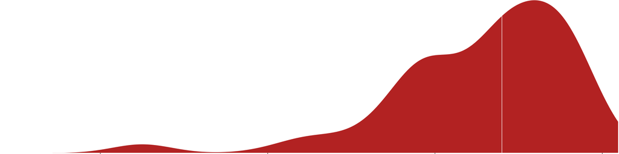

3. BIER

1986.0

1984.50

5.83

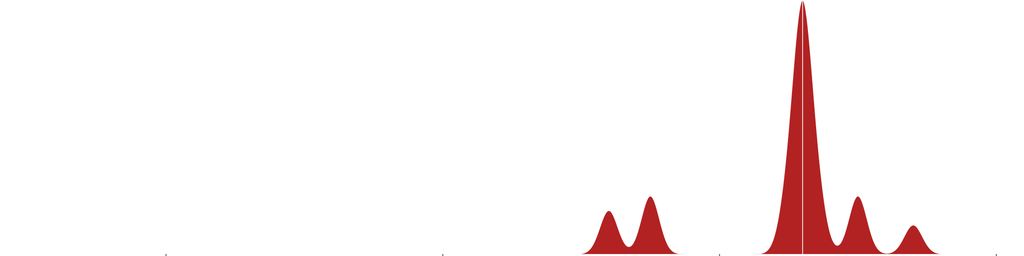

4. LINKS

1983.0

1978.02

16.36

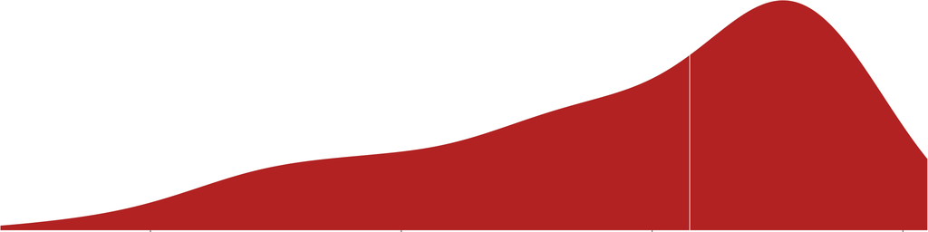

5. WIFF

1981.0

1975.00

26.75

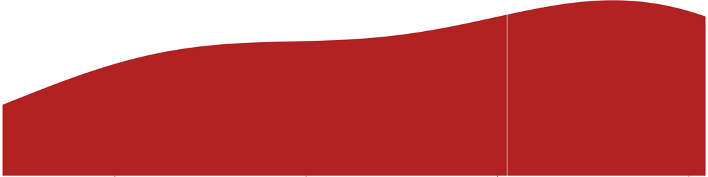

6. NEOS

1977.0

1977.59

13.20

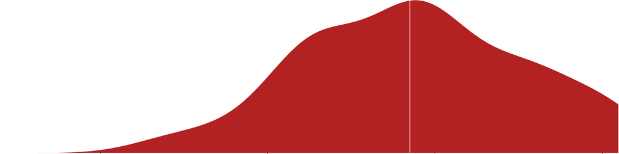

7. SPÖ

1976.0

1975.66

12.42

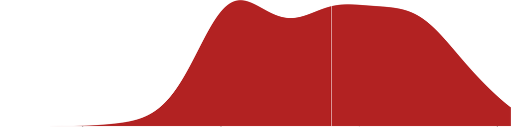

8. ÖVP

1975.0

1975.26

16.06

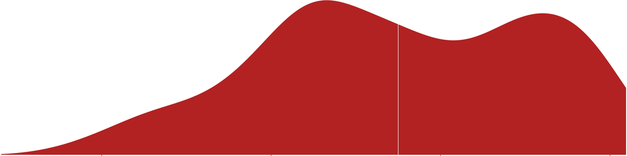

9. GRÜNE

1973.0

1973.43

12.83

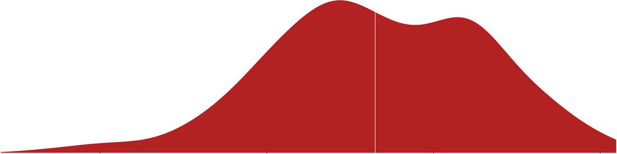

10. FPÖ

1970.0

1971.81

14.96

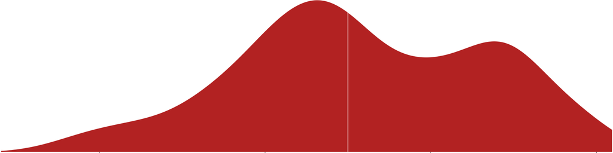

11. HC

1968.0

1970.49

12.92

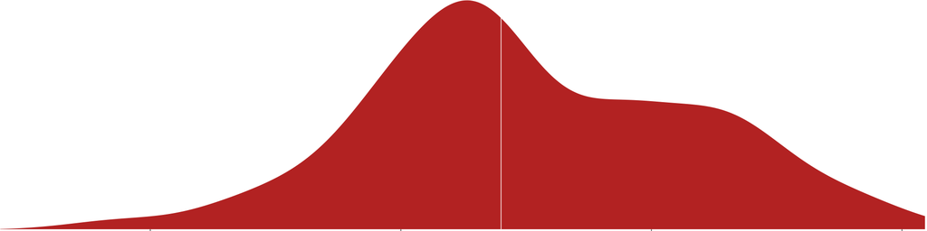

12. PRO

1959.0

1963.27

13.30

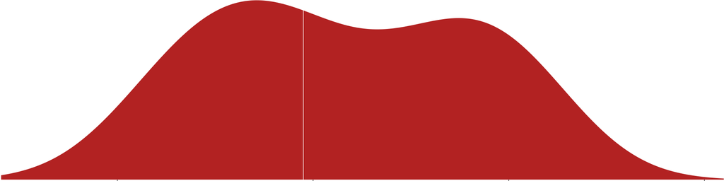

Bezirksvertretungen

1. VOLT

1992.0

1992.27

4.18

[figure not shown]

2. WANDL

1990.0

1986.62

12.73

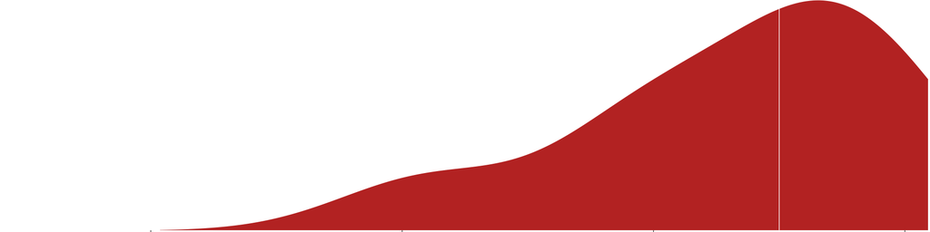

3. KURZ

1989.0

1987.71

7.90

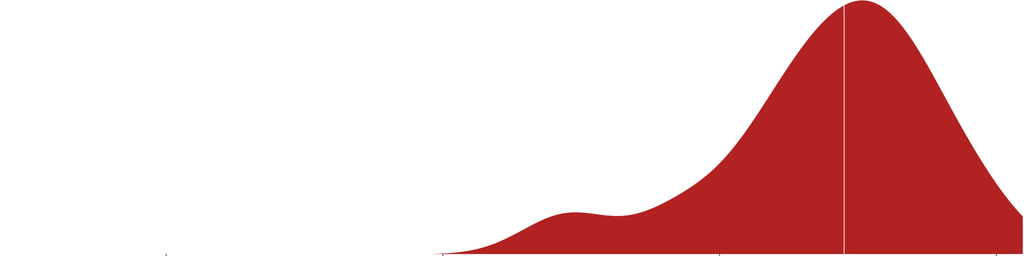

4. SÖZ

1988.0

1985.35

11.17

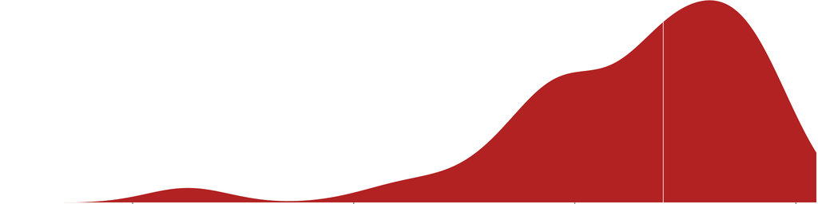

5. BIER

1986.0

1986.77

3.26

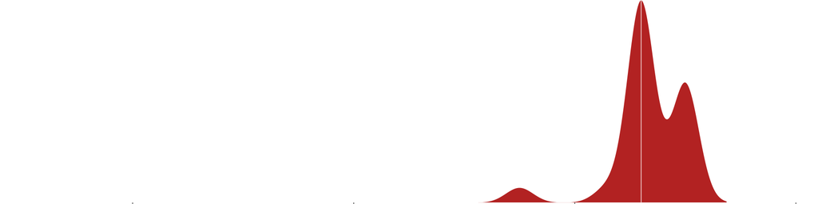

6. LINKS

1985.0

1979.47

15.52

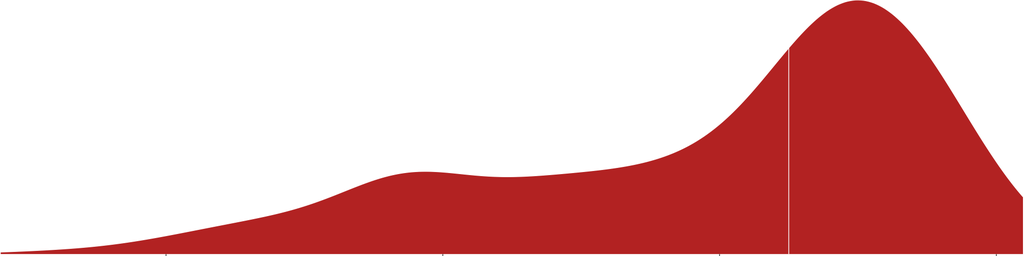

7. NEOS

1980.0

1979.68

14.28

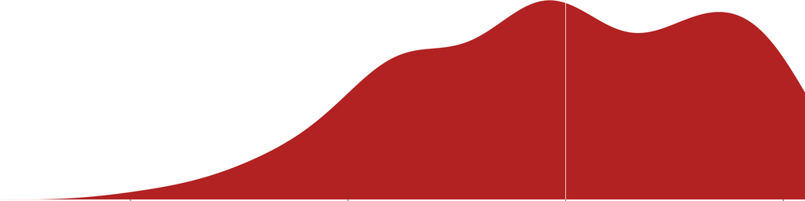

8. GRÜNE

1973.0

1973.55

13.48

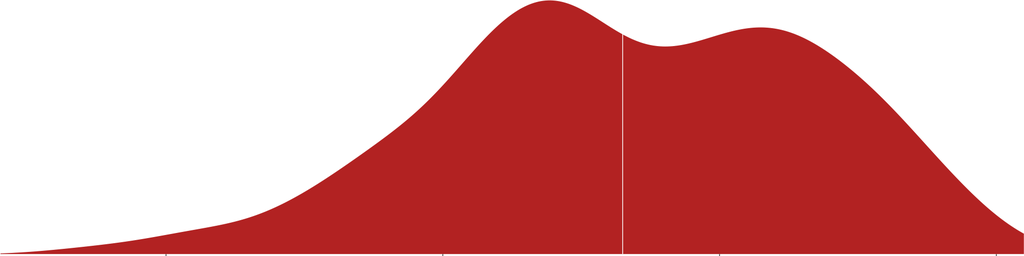

9. SPÖ

1972.0

1972.73

15.30

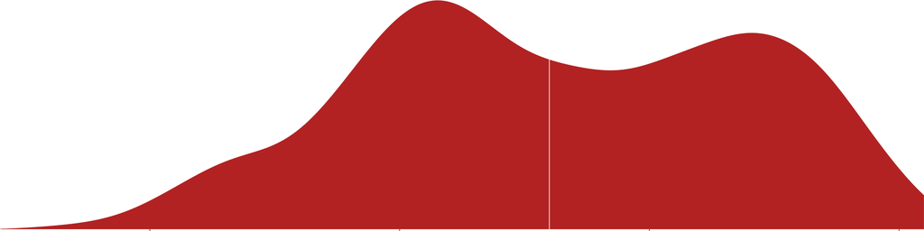

9. ÖVP

1972.0

1972.44

18.37

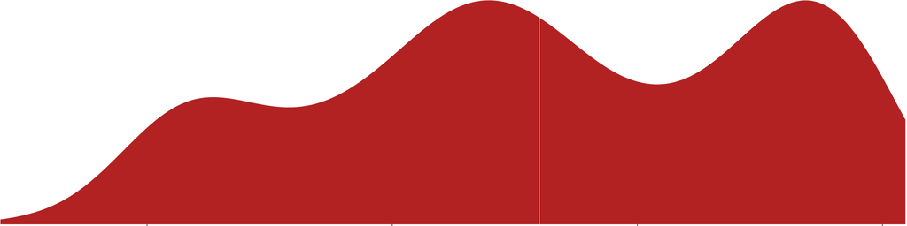

11. PdA

1969.0

1967.67

13.05

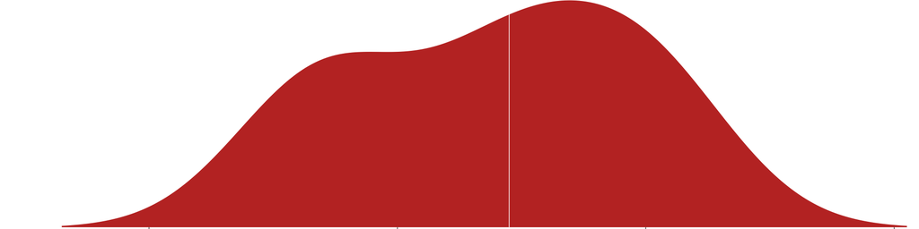

12. WIR

1968.5

1969.25

5.95

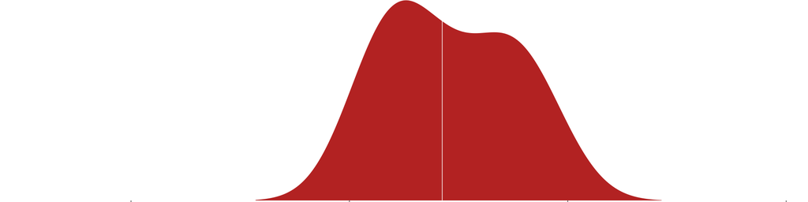

13. FPÖ

1968.0

1969.75

16.46

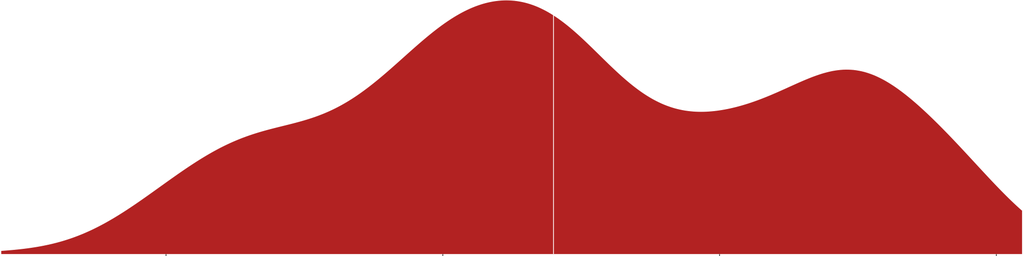

13. HC

1968.0

1970.16

12.91

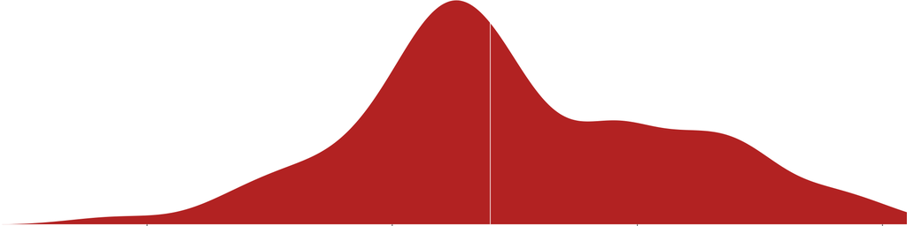

13. VOLK

1968.0

1970.67

15.18

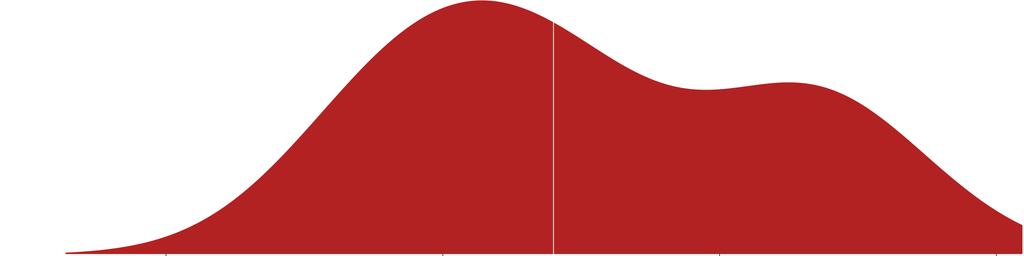

16. PRO

1964.5

1964.33

13.21

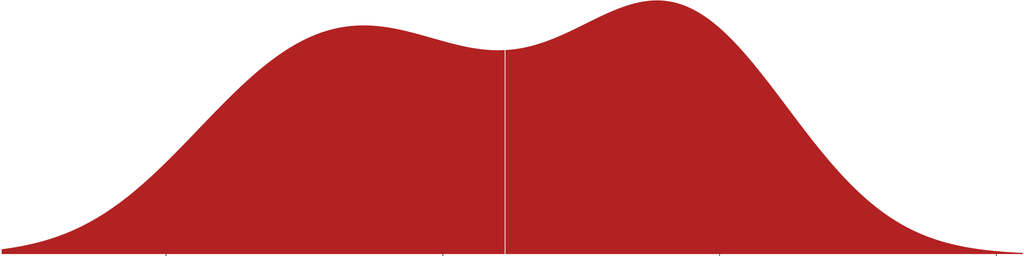

17. WIEN

1960.0

1958.67

7.89

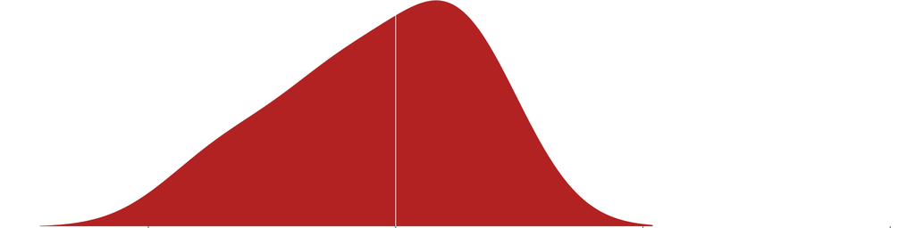

18. WIFF

1958.0

1961.77

20.93

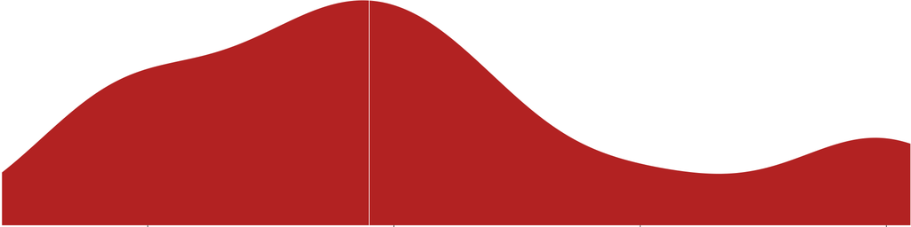

19. PH

1955.0

1957.40

5.94

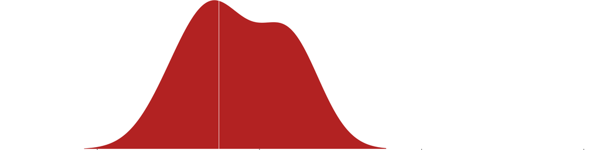